# Analysis of how severe weather events are impacting US population health

Krisztian Gyuris

24 Jan 2015

## Synopsis

The goal of this report to show the most harmfull events that can be affect the health of united states population. Inorder to investigate this hypothesis we have gathered the data from U.S. National Oceanic and Atmospheric Administration’s (NOAA) storm database. The events in the database start in the year 1950 and end in November 2011. This database tracks characteristics of major storms and weather events in the United States, including when and where they occur, as well as estimates of any fatalities, injuries, and property damage. From this data the **TORNADO** seems to have the greatest health impact. The biggest economical impact is caused by **FLOOD** according to the data.

## Data Processing

### Basic Setup

Importing libraries, setting up some basic variables.

```r
setwd('/Users/krisztiangyuris/dev/datasciencecoursera/RepData_PeerAssessment2')
library(R.utils)
```

```r
library(ggplot2)
library(knitr)
opts_chunk$set(echo=TRUE, cache=TRUE)
```

### Loading the Data

Loading and cleaning the data

```r
cache=TRUE
bunzip2("repdata-data-StormData.csv.bz2", overwrite=T, remove=F)
stormData <- read.csv("repdata-data-StormData.csv")
```

Getting the columns that are interesting for us and cleaning them up.

```r
stormData <- stormData[, c("EVTYPE", "FATALITIES", "INJURIES", "PROPDMG", "PROPDMGEXP", "CROPDMG", "CROPDMGEXP")]
stormData$EVTYPE <- toupper(stormData$EVTYPE)
stormData$PROPDMGEXP <- toupper(stormData$PROPDMGEXP)
stormData$CROPDMGEXP <- toupper(stormData$CROPDMGEXP)
```

Correcting the event type names

```r
stormData[grep("TORNADO*|TORNDAO*",stormData$EVTYPE),c("EVTYPE")] <- "TORNADO"
stormData[grep("HURRICANE*",stormData$EVTYPE),c("EVTYPE")] <- "HURRICANE"
stormData[grep("HAIL*",stormData$EVTYPE),c("EVTYPE")] <- "HAIL"
stormData[grep("HEAVY RAIN*|HVY RAIN*",stormData$EVTYPE),c("EVTYPE")] <- "HEAVY RAIN"
stormData[grep("WATERSPOUT*",stormData$EVTYPE),c("EVTYPE")] <- "WATERSPOUT"
stormData[grep("THUNDERSTORM WINDS*|THUNDERSTORM WIN*|TSTM WIND|TSTMW*",stormData$EVTYPE),c("EVTYPE")] <- "THUNDERSTORM WIND"
stormData[grep("THUNDEERSTORM*|THUNDERESTORM*|THUNDERTORM*|THUNERSTORM*|THUNDERSTROM*",stormData$EVTYPE),c("EVTYPE")] <- "THUNDERSTORM WIND"
stormData[grep("RIP CURRENT*",stormData$EVTYPE),c("EVTYPE")] <- "RIP CURRENT"
stormData[grep("STRONG WIND*",stormData$EVTYPE),c("EVTYPE")] <- "STRONG WIND"
stormData[grep("LIGHTNING*|LIGHTIN*|LIGNTNING*",stormData$EVTYPE),c("EVTYPE")] <- "LIGHTNING"
stormData[grep("FLASH FLOOD*",stormData$EVTYPE),c("EVTYPE")] <- "FLASH FLOOD"
stormData[grep("WINTER WEATHER*",stormData$EVTYPE),c("EVTYPE")] <- "WINTER WEATHER"
stormData[grep("WINTER STORM*",stormData$EVTYPE),c("EVTYPE")] <- "WINTER STORM"
stormData[grep("TROPICAL STORM*",stormData$EVTYPE),c("EVTYPE")] <- "TROPICAL STORM"
stormData[grep("HEAVY SNOW*",stormData$EVTYPE),c("EVTYPE")] <- "HEAVY SNOW"
stormData[grep("WILDFIRE*|WILD FIRE*|WILD/FOREST*",stormData$EVTYPE),c("EVTYPE")] <- "WILD FIRE"
stormData[grep("FLOODING|FLOOD/RIVER FLOOD|FLOODS|FLOOD/RAIN/WINDS",stormData$EVTYPE),c("EVTYPE")] <- "FLOOD"
stormData[grep("HEAVY RAIN*|HVY RAIN|RAIN (HEAVY)",stormData$EVTYPE),c("EVTYPE")] <- "HEAVY RAIN"
```

Fixing the exponents for both property and crop damage figures.

```r
stormData$PROPDMGEXP = as.character(stormData$PROPDMGEXP)
stormData$PROPDMGEXP[stormData$PROPDMGEXP=='H'] = "2"
stormData$PROPDMGEXP[stormData$PROPDMGEXP=='K'] = "3"
stormData$PROPDMGEXP[stormData$PROPDMGEXP=='M'] = "6"
stormData$PROPDMGEXP[stormData$PROPDMGEXP=='B'] = "9"
stormData$PROPDMGEXP[stormData$PROPDMGEXP==''] = "0"
stormData$PROPDMGEXP = as.numeric(stormData$PROPDMGEXP)
stormData$PROPDMGEXP[is.na(stormData$PROPDMGEXP)] = 0

stormData$CROPDMGEXP = as.character(stormData$CROPDMGEXP)
stormData$CROPDMGEXP[stormData$CROPDMGEXP=='H'] = "2"
stormData$CROPDMGEXP[stormData$CROPDMGEXP=='K'] = "3"
stormData$CROPDMGEXP[stormData$CROPDMGEXP=='M'] = "6"
stormData$CROPDMGEXP[stormData$CROPDMGEXP=='B'] = "9"
stormData$CROPDMGEXP[stormData$CROPDMGEXP==''] = "0"
stormData$CROPDMGEXP = as.numeric(stormData$CROPDMGEXP)
stormData$CROPDMGEXP[is.na(stormData$CROPDMGEXP)] = 0
```

Creating property, crop and total damage columns.

```r
stormData$PropertyDamage = stormData$PROPDMG * 10^stormData$PROPDMGEXP
stormData$CropDamage = stormData$CROPDMG * 10^stormData$CROPDMGEXP
stormData$TotalDamage = stormData$PropertyDamage + stormData$CropDamage
```

## Results

### Most harmful events to population health

Adding together fatalities and injuries and printing the top 10 events ordered by health impact.

```r
stormData$HealthImpact = stormData$FATALITIES + stormData$INJURIES
healthImp <- tapply(stormData$HealthImpact, stormData$EVTYPE, sum)
healthImpDF <- data.frame(eventtype=names(healthImp), impact=as.numeric(healthImp))
healthImpDF <- healthImpDF[order(healthImpDF$impact,decreasing=TRUE),]
```

Across the United States, the following types of events are most harmful with respect to population health.

```r
healthImpDF <- healthImpDF[1:10,]
print(healthImpDF)
```

```
##             eventtype impact
## 518           TORNADO  97068
## 507 THUNDERSTORM WIND  10122
## 100    EXCESSIVE HEAT   8428
## 123             FLOOD   7281
## 280         LIGHTNING   6048
## 170              HEAT   3037
## 122       FLASH FLOOD   2837
## 253         ICE STORM   2064
## 582         WILD FIRE   1696
## 593      WINTER STORM   1570
```

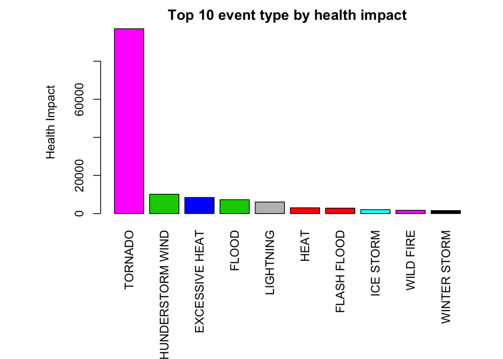

```r
par(mar=c(10,7,2,2), las=3)
barplot(healthImpDF$impact, names.arg=healthImpDF$eventtype, col=healthImpDF$eventtype, ylab="Health Impact", main="Top 10 event type by health impact")
```

The top harmfull event is **TORNADO**

### Events with the greates economic impact

```r
economyImp <- tapply(stormData$TotalDamage, stormData$EVTYPE, sum)
economyImpDF <- data.frame(eventtype=names(economyImp), impact=as.numeric(economyImp))
economyImpDF <- economyImpDF[order(economyImpDF$impact,decreasing=TRUE),]
```

Across the United States, the following types of events have the greatest economic consequences.

```r
economyImpDF <- economyImpDF[1:10,]
print(economyImpDF)
```

```
##             eventtype       impact
## 123             FLOOD 150890712877
## 240         HURRICANE  90271472810
## 518           TORNADO  59020779946
## 428       STORM SURGE  43323541000
## 167              HAIL  19134704410
## 122       FLASH FLOOD  19120477246
## 69            DROUGHT  15018672000
## 507 THUNDERSTORM WIND  11119650814
## 365       RIVER FLOOD  10148404500
## 253         ICE STORM   8967041360
```

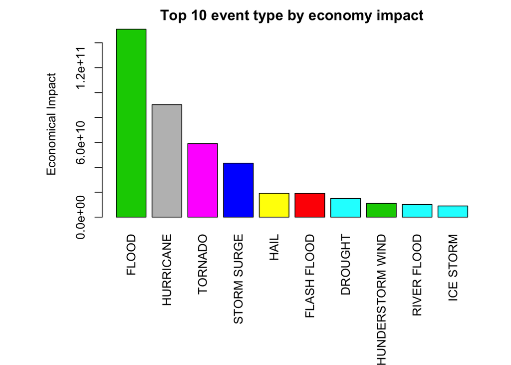

```r
par(mar=c(10,7,2,2), las=3)
barplot(economyImpDF$impact, names.arg=economyImpDF$eventtype, col=economyImpDF$eventtype, ylab="Economical Impact", main="Top 10 event type by economy impact")
```

The top harmfull event is **FLOOD** by economy impact.